# IODS course project

Petteri MOilanen

# 1. Introduction to Open Data Science

After completing this course you will understand the principles and advantages of using open research tools with open data and understand the possibilities of reproducible research.

[Link to my repo](https://github.com/P3tt3ri/IODS-project)

# 2. Regression and model validation

**(Note to viewer: this version is slightly incomplete, especially “2.4 Explaining the relationships”.)**

## 2.1 Reading in the data

First I read the wrangled data from my project folder:

```r
l14 <- read.csv2("~/GitHub/IODS-project/data/learning2014.csv", header=TRUE)
```

## 2.2 Overview of the data

The data is from a study by Kimmo Vehkalahti: “The relationship between learning approaches and students’ achievements in an introductory statistics course in Finland”. A short presentation of the study can be found [here:](https://www.slideshare.net/kimmovehkalahti/the-relationship-between-learning-approaches-and-students-achievements-in-an-introductory-statistics-course-in-finland)

Summary of the variables:

```r
summary(l14)
```

```
##  gender       age           attitude          deep            stra
##  F:110   Min.   :17.00   Min.   :1.400   Min.   :1.583   Min.   :1.250
##  M: 56   1st Qu.:21.00   1st Qu.:2.600   1st Qu.:3.333   1st Qu.:2.625
##          Median :22.00   Median :3.200   Median :3.667   Median :3.188
##          Mean   :25.51   Mean   :3.143   Mean   :3.680   Mean   :3.121
##          3rd Qu.:27.00   3rd Qu.:3.700   3rd Qu.:4.083   3rd Qu.:3.625
##          Max.   :55.00   Max.   :5.000   Max.   :4.917   Max.   :5.000
##       surf           points
##  Min.   :1.583   Min.   : 7.00
##  1st Qu.:2.417   1st Qu.:19.00
##  Median :2.833   Median :23.00
##  Mean   :2.787   Mean   :22.72
##  3rd Qu.:3.167   3rd Qu.:27.75
##  Max.   :4.333   Max.   :33.00
```

A data frame of 166 observations and seven variables:

1. Gender
2. Age
3. Attitude - the subject’s general attitude towards statistics. Summed up from up from various various variables of the original study and scaled to 1-5. 1 means very negative attitude and 5 very positive. Same goes for the the the next three variables.
4. The extent of the subject’s level of commitment to deep learning approach.
5. The extent of the subject’s level of commitment to strategic learning approach.
6. The extent of the subject’s level of commitment to surface learning approach.
7. The best point score on the course exam (several tries possible).

Scatter plot matrix:

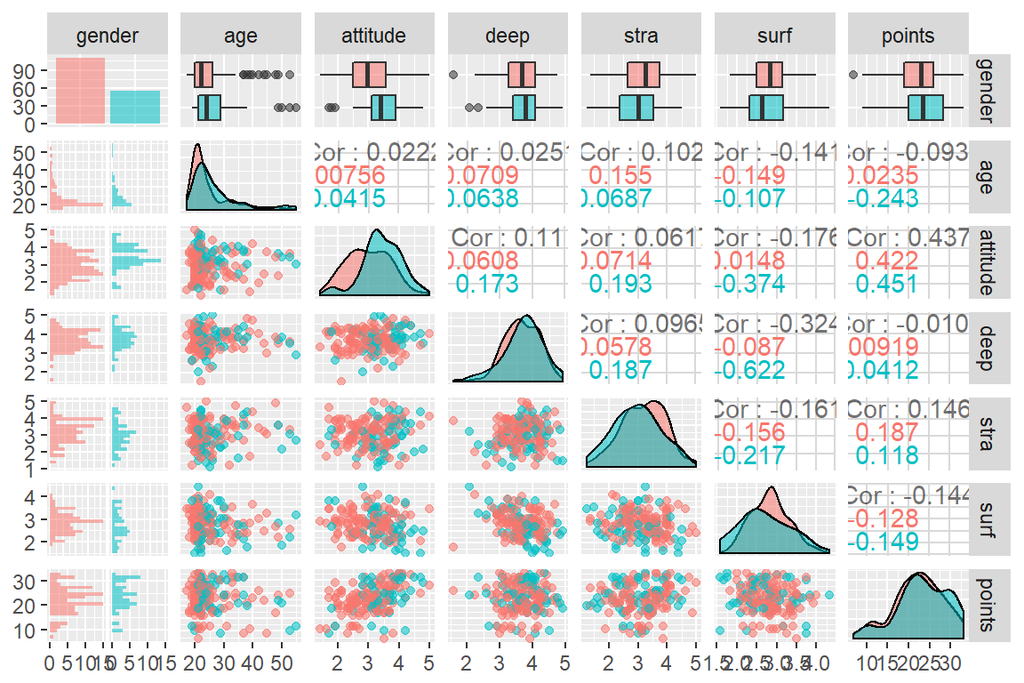

```r
library(ggplot2)
library(GGally)
p <- ggpairs(l14, mapping = aes(col=gender, alpha=0.3), lower = list(combo = wrap("facethist", bins = 20)))
p
```

Some observations on the data:

- Two thirds of the sample are female which corresponds pretty well with the gender percenteges of Social Sciences students, the main source of the subjects.
- Age is a right-skewed (median smaller than mean).

```r
table(cut(l14$age, breaks = seq(15,55,by=10)))
```

```
##
## (15,25] (25,35] (35,45] (45,55]
##     116      32      11       7
```

- The distribution of the attitude is quite different between males and females:

```r
table(l14$gender, cut(l14$attitude, breaks = seq(1,5,by=0.5)))
```

```
##
##     (1,1.5] (1.5,2] (2,2.5] (2.5,3] (3,3.5] (3.5,4] (4,4.5] (4.5,5]
##   F       1      11      22      25      23      21       5       2
##   M       0       3       1       6      23      13       8       2
```

With females, the distribution is almost textbook normal. With males it’s skewed left.

```r
table(l14$gender, cut(l14$surf, breaks = seq(1,5,by=0.5)))
```

```
##
##     (1,1.5] (1.5,2] (2,2.5] (2.5,3] (3,3.5] (3.5,4] (4,4.5] (4.5,5]
##   F       0       3      29      49      23       6       0       0
##   M       0       8      17      15      10       5       1       0
```

## 2.3 Building the model

```r
my_model <- lm(points ~ attitude + surf + stra, data = l14)
summary(my_model)
```

```
##
## Call:
## lm(formula = points ~ attitude + surf + stra, data = l14)
##
## Residuals:
##      Min       1Q   Median       3Q      Max
## -17.1550  -3.4346   0.5156   3.6401  10.8952
##
## Coefficients:
##             Estimate Std. Error t value Pr(>|t|)
## (Intercept)  11.0171     3.6837   2.991  0.00322 **
## attitude      3.3952     0.5741   5.913 1.93e-08 ***
## surf         -0.5861     0.8014  -0.731  0.46563
## stra          0.8531     0.5416   1.575  0.11716
## ---
## Signif. codes:  0 '***' 0.001 '**' 0.01 '*' 0.05 '.' 0.1 ' ' 1
##
## Residual standard error: 5.296 on 162 degrees of freedom
## Multiple R-squared:  0.2074, Adjusted R-squared:  0.1927
## F-statistic: 14.13 on 3 and 162 DF,  p-value: 3.156e-08
```

The only variable with statistically significant effect on points is attitude, so I dropped surf and stra.

```r
my_model <- lm(points ~ attitude, data = l14)
summary(my_model)
```

```
##
## Call:
## lm(formula = points ~ attitude, data = l14)
##
## Residuals:
##      Min       1Q   Median       3Q      Max
## -16.9763  -3.2119   0.4339   4.1534  10.6645
##
## Coefficients:
##             Estimate Std. Error t value Pr(>|t|)
## (Intercept)  11.6372     1.8303   6.358 1.95e-09 ***
## attitude      3.5255     0.5674   6.214 4.12e-09 ***
## ---
## Signif. codes:  0 '***' 0.001 '**' 0.01 '*' 0.05 '.' 0.1 ' ' 1
##
## Residual standard error: 5.32 on 164 degrees of freedom
## Multiple R-squared:  0.1906, Adjusted R-squared:  0.1856
## F-statistic: 38.61 on 1 and 164 DF,  p-value: 4.119e-09
```

## 2.4 Explaining the relationships

R-squared is pretty low, so attitude doesn’t explain a large portion of the variance of the test points.